# Analysis of Investment Outcome Predictor Report

Nikko Dumrique, Mahdi Heydar, Harry Zhang, Ahmed Rizk

## Summary

The goal of this analysis is to investigate the economic family’s investment income, where the true class indicates money was made on investments, and the false class indicates breaking even or money lost. The report examines its relationship with family size, the economic family’s major income earner, the income after tax, and other related variables to determine whether or not its possible to predict it using those variables or a subset of them. The data is obtained from Statistics Canada’s 2017 Canadian Income Survey (S. Canada 2019).

## Introduction

It is estimated that roughly 39% of Canadians invest in stocks, putting Canada in 6th place among 16 countries for share of retail investors (Professional 2021). As every generation makes their first investments earlier than their predecessors (B. Canada 2013), the importance of gauging and predicting the success of said investments arises.

Families of most wealth levels and sizes have been steadily placing an emphasis on maintaining passive income and generational wealth, through a variety of ways that range from real estate ownership to family offices (Blog 2021). In this analysis, we are particularly interested in the family size and its relationship to the investment income.

The economic family is defined by Statistics Canada as “a group of two or more persons who live in the same dwelling and are related to each other by blood, marriage, common-law union, adoption or a foster relationship” (S. Canada 2020).

We will examine the investment income of the economic family with the aim of identifying whether or not we can predict it using the economic family size and the major income earner.

There are other variables of interest that may also be useful in the context of the predictive analysis. We hypothesize that the average number of weekly working hours for the major source of income, their highest level of education and their income after tax may affect the economic family’s investment income. Furthermore, the economic family’s income after tax may be a strong candidate as a predictor variable, although there are some reservations due to it possibly being too collinear with the investment income.

## Research Question

- How do economic family size and the major income earner in a family influence familial investment income outcome, where the true class indicates money was made on investments, and the false class indicates breaking even or money lost.
  - It should be noted that the question initially aimed to predict the numerical value of the investment, but the accuracy obtained showed a regression problem to be unsuitable (see report), so the problem was altered to a classification problem.

## Dataset Description

Canadian Income Survey (CIS) (S. Canada 2019) is a cross-sectional survey sponsored both by the Government of Canada and Statistics Canada. The purpose of this survey is to collect information from all Canadian citizens and households. However, around 2% of the residents in reserve aboriginal settlements or small population, extremely remote areas are not included in this survey. The data was collected with several different characteristics in mind including labour market activity, school attendance, disability, support payments, child care expenses, inter-household transfers. It also combines some information from the Labour Force Survey (LFS), such as the information about the education level and geography. This data set is available to all organizations, different levels of the government, and individuals. Different government levels could use this dataset to make economic well policies to all Canadians.

### Description of Relevant Variables

The original dataset contains 194 variables. However, our analysis is only concerned with 8, narrowed down using the aforementioned studies and assumptions. The description contains only those specified variables.

### Cleaning and Wrangling

The data is reduced to some specific features and targets of interest before EDA, using the studies around the research question to narrow them down from 194 features to the most relevant 8.

### Variable Data types and Modifications

[figure not shown]

Figure 1: Frequency Distributions of the chosen variables

##### Note: correlations between categorical features should be ignored as these are invalid

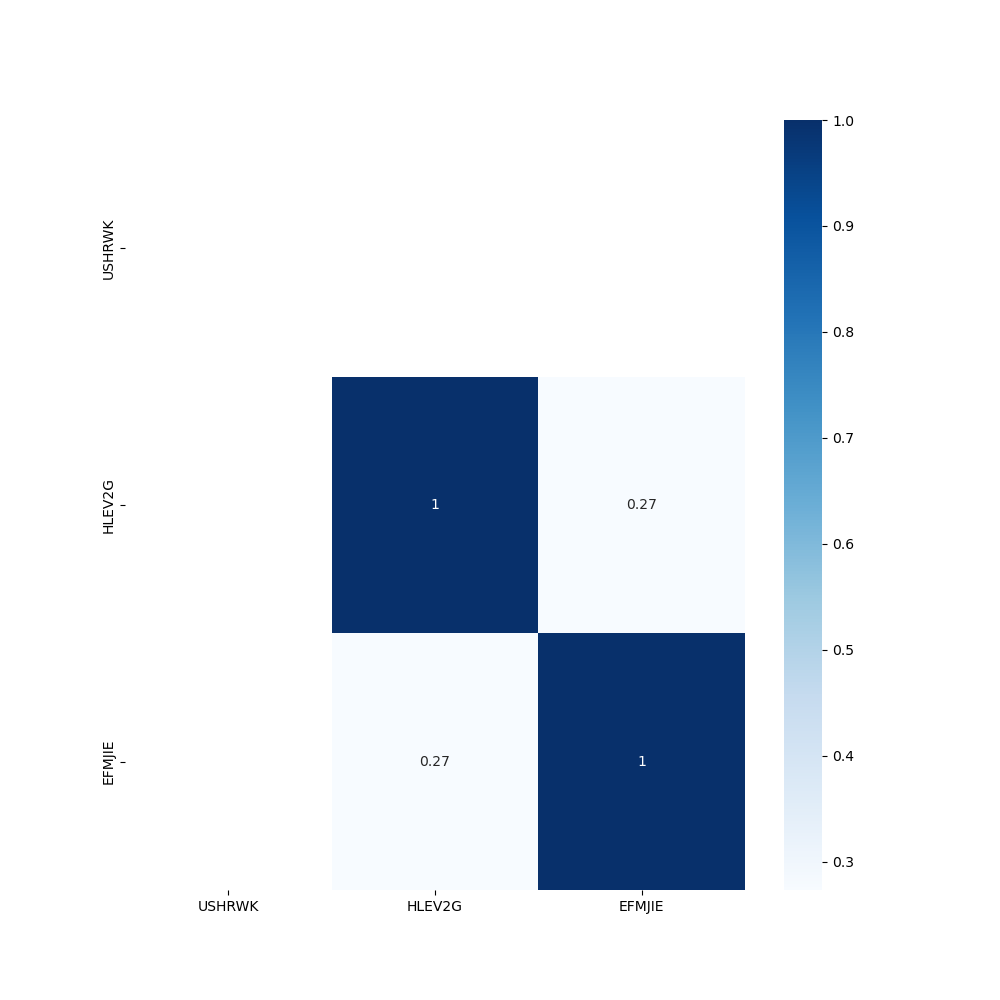

Figure 2: Matrix of correlations between various features

## Methods and Results

### Data Splitting and Preprocessing

The ratio of the train/test split was chosen as 70/30 to achieve the best balance between model accuracy and testing accuracy. In order to make sure that we can preprocess our training data, we have to separate it into two parts each representing the X variable and the Y variable. We also repeat process for the test data.

We build a transformer to do ordinal encoding. As for better machine readability, we need to make our variables start from 0 instead of 1.

### The First Model: Ridge Regression

#### Hyperparameter Optimization

We use cross validation to improve the prediction accuracy. The tuning process is to find the best alpha value, which is then used to create the model.

We found the cross validation (CV) scores as follows. Then we create a reverse elbow plot to find the best number cross validation folds.

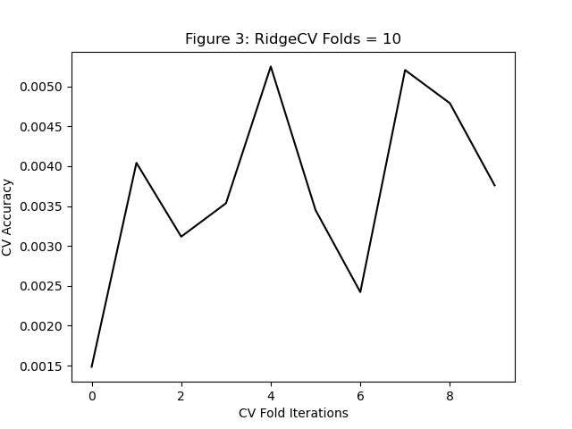

Figure 3: Cross Validation Accuracy vs Fold Iterations

### Second Model: KNN-Classification Figure 4

We hypothesize that our model’s weakness may be due to the exclusive use of categorical and low range discrete variables. Since our continuous options (EFATINC) and (ATINC) will not be suitable predictors for our response variable in this case, we can change the model to a classification. Building a model that predicts whether or not the economic family made investment profit may be a better method to investigate the relationship given the predictor variables we are working with. Therefore we convert our response variable into the new variable “EFINVA_Made_Money”.

The same splitting methodology has been applied here as in the regression model.

Next, we tune the model to find the best value of K neighbors.

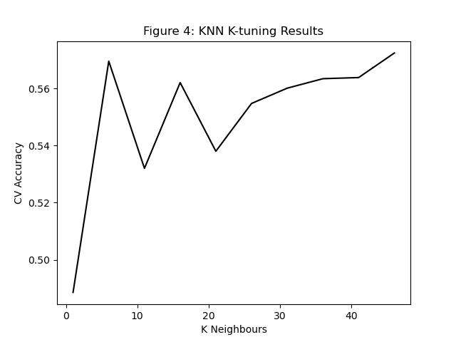

Figure 4: Elbow plot of K-values vs CV accuracy

#### Testing Score

The model shows an accuracy of 0.5572705 percent on the testing data, which is very slightly better than arbitrary guessing.

#### Classification Results Visualization

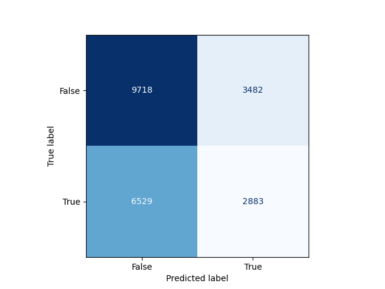

Figure 5: Confusion Matrix

#### Discussion of Plot Results

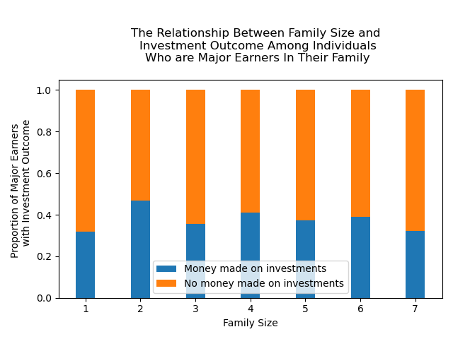

Figure 6: The actual investment results among major earners

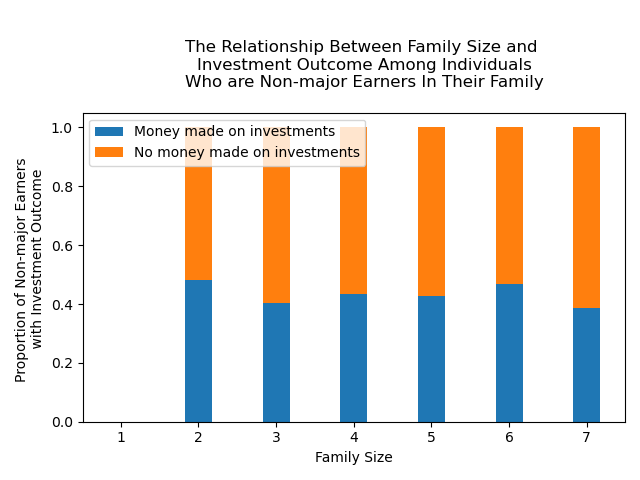

Figure 7: The actual investment results among non-major earners

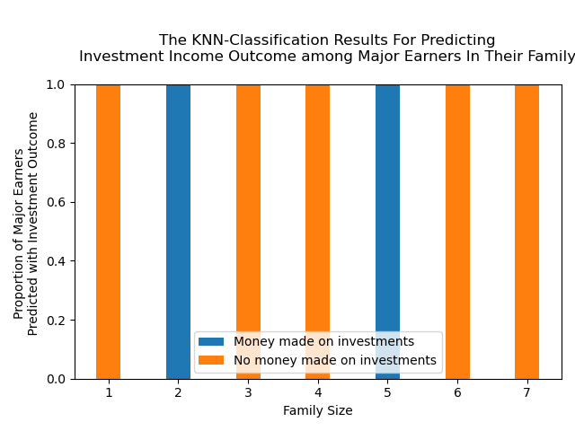

Figure 8: The predicted investment results among major earners

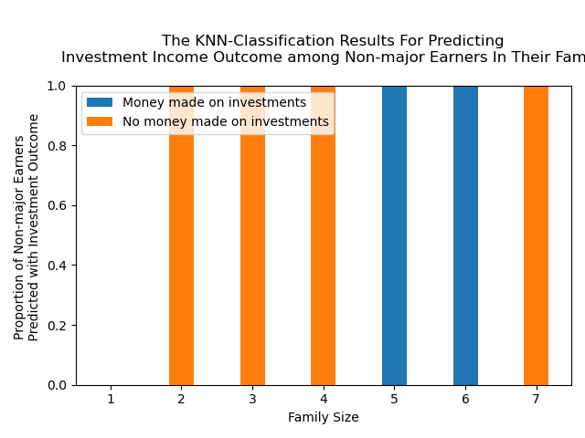

Figure 9: The predicted investment results among non-major earners

Figure 6 and Figure 7 show the actual results from the test data for investment income outcomes among major earners and non major earners respectively. Both figures show families of size 2, 4 and 6 to have the largest proportions of people making money from investments while families of 7 have the lowest proportions of individuals making money. However, among the non-major income earners, the proportions of individuals making money is generally slightly higher. Nevertheless, The percentages either breaking even or losing money on their investments is larger among a majority of the family sizes in both cases. A key difference is also present among non major earners where families of 1 are non existant. This is logical within this context since a family consisting of one person automatically makes that person the major earner.

## Discussion of Overall Results:

Using two different models, we concluded that the relationship between the Economic Family’s Investment Income, size, and major income source is very weak. This was unexpected, as the original assumption of high correlation between the variables was disproven.

The relative improvement in the accuracy of the KNN classification model compared to the Regression model may indicate that the predictor variables are better at predicting whether or not the economic family made profits through investment, than they are at predicting the magnitude of said profits/losses.

The design decision to eliminate the Economic Family’s Income After Tax from the list of predictor variables, due to low correlation, may have negatively affected the accuracy of both models. Prior to starting the analysis, it was assumed that it would be too collinear with the response variable. However, the correlation coefficients showed this not to be the case. A possible explanation is that the economic family’s income before tax is what suffers from this multicollinearity with the investment income, due to the latter being one of the many contributing incomes to the sum that makes it up. The removal of tax may offset this multicollinearity to a strong enough degree that it would make for better predictive models, and the degree of this change may be an interesting topic for a future study.

A further point of discussion is the age of the dataset, as the data was collected prior to the cryptocurrency boom in 2017. Some of the data regarding the relationships surrounding the investment income (direct or indirect) may be outdated.

In the future, Data Scientists studying investment income of Canadian Families may refrain from dedicating significant resources to using the family’s size and major source of income as possible predictors, due to the lack of evidence for a relationship between them exemplified through the analysis.

Additionally, it may encourage more studies surrounding investment income of individuals as opposed to that of families, which may lead to different results due to variables such as the investor’s highest education level and sex being more relevant. It may also better fit the investor’s status as the major income earner of the economic family, as its lack of relationship with the family’s investment income may indicate more suitability in a study about the individual rather than the family

## References:

Blog, KPMG In Canada. 2021. “The Rise of the Family Office in Canada.” KPMG In Canada Blog. https://home.kpmg/ca/en/blogs/home/posts/2021/06/the-rise-of-the-family-office-in-canada.html.

Canada, Benefits. 2013. “Millennials Invest Early Think Long Term.” Benefits Canada. https://www.benefitscanada.com/news/bencan/millennials-invest-early-think-long-term/.

Canada, Statistics. 2019. “Canadian Income Survey (CIS), 2017.” Abacus Data Network. https://doi.org/11272.1/AB2/HFWKLV.

———. 2020. “Total Income of the Economic Family.” Statistics Canada. https://www23.statcan.gc.ca/imdb/p3Var.pl?Function=DEC&Id=103378.

Professional, Wealth. 2021. “More Than Half of Canadians Plan to Own Shares by Year-End.” Industry News. https://www.wealthprofessional.ca/news/industry-news/more-than-half-of-canadians-plan-to-own-shares-by-year-end/359479.